# Project - AMOD 5250H

Madhu Garg

release date: 18/12/2019

# Data Summary

## Introduction

The American Community Survey (ACS) interviews people across the USA and provides insight into the US population. This helps local officials, community leaders, and businesses understand the changes taking place in their communities. It is the most authentic source for detailed population and housing information about the United States of America.

ACS also makes survey data available to the public. Anyone across the world can download this data from the website. The 2017 American Community Surveys(ACS)- 5-year Public Use Microdata Samples (PUMS) available on the website are samples of the actual responses collected by the American Community Survey between 2013-2017.

*PUMS Dataset Characteristics*

1. The PUMS dataset is very detailed and includes data for nearly every question on the survey. In fact it also include many new variables that were derived from multiple survey responses.
2. PUMS files for one year contain data on approximately one percent of the United States population. Thus the PUMS files covering a five-year period, such as 2013-2017, contain data on approximately five percent of the United States population.
3. PUMS files are however a little complicated to use as data is not a one-to-one mapped with the respondents.
4. As ACS has to keep all the responses strictly confidential, many variables in the PUMS files have been modified. For instance, incomes are “top-coded,” and uncommon birthplace or ancestry responses are grouped into broader categories.

*PUBLIC USE MICRODATA AREAS (PUMAS)*

The most detailed unit of data contained in the PUMS files is the Public Use Microdata Area (PUMA). PUMAs are special non-overlapping areas that partition each state into continuous geographic units. Each unit contains no fewer than 100,000 people.

## Problem Statement

Since the data stores detailed demographic, health, personnel, income and other characteristics of people and households, this data is used as a major source for doing any people or household related analysis in the USA.

This data also contains detailed information about the people who are suffering from any kind of disabilities. The purpose of this project is to use the disability information to do an exploratory analysis of the people who are suffering from disabilities.

The main objectives are :

1. Study the disability pattern in the adult population (>18) in America.
2. Compare the income of people suffering from disabilites within themselves.
3. Identify the important factors that influence the income of disabled people.

## Dataset Description

PUMS person dataset is used in this research. This dataset has 52 variables. Items in the ‘person’ record include information about the person and the household. Few of the important subjects are - Marital status and marital history, Income, Disability, Occupation, Education, Sex, Citizenship etc. There is a large amount of other important information that is captured in this survey. The data available for public use is stored in four large files. So for any country wide analysis, it is important to read records from all four files and merge it into one big dataset.

The fields used in this project are given below

```
  DIVISION  -  Division code based on 2010 Census definitions
  ST     - State code based on 2010 Census definitions code
  ADJINC - Adjustment factor for income and earnings dollar amounts
  PWGTP  - Person weight. Actual number of people  a record in the data file represent
  AGEP   - Age of a person
  CIT    - Citizenship status
  DDRS   - Self-care difficulty
  DREM   - Cognitive  difficulty.
  DPHY   - Ambulatory difficulty.
  DOUT   - Independent living difficulty
  DEYE   - Vision difficulty
  DEAR   - Hearing difficulty
  DIS    - Disability recode
  ENG    - Ability to speak English
  INTP   - Interest, dividends, and net rental income past 12 months
  OIP    - All other income past 12 months
  RETP   - Retirement income past 12 months
  SEMP   - Self-employment income past 12 months
  WAGP   -  Wages or salary  income past 12 months
  PINCP  - Total person's income past 12 months
  SCHL   - Educational attainment
  SEX    - Sex of the person
```

The detailed definition of these fields are stored in the appendix.

## Dataset Creation

Since the dataset is large, the reading of data files is performed in two steps.

Step 1 : A very small number of records are fetched from each file to check the data structure and file consistencies. The total number of columns and order of columns are matched.

Step 2 : This step comprises constructing an array of variables that are to be used in the project. Only these variables are read from the files. The records of people having disabilities are extracted from the file. Remaining records are removed from the memory. This helps in efficient reading of the records. The final dataset is created by merging stored records.

These two steps are executed in the below section:

*Step 1 : Fetch the data from 4 files :*

```r
# Code here
# set systems options
options(scipen=999,"digits"=5)

# Set the working directory for files
#setwd("D://rclass/ProjectCourse")

# Create a vector of fields name used in datafiles for storing disabilties and
# income information.
# combine it with the common person record variables to get the final set of fields

dis.param    <-  c("DDRS","DEAR","DEYE", "DOUT","DPHY","DREM")
income.param <-  c("ADJINC", "INTP","OIP", "RETP", "SEMP", "WAGP","PINCP","PWGTP")
initial.param <-  c("DIVISION","ST","DIS","AGEP","CIT","SEX","ENG", "SCHL",
                      dis.param,income.param)

# Fetch 200 records check the consistency of the files and compare the columnn.

pusa.200row <- read.csv("psam_pusa.csv", nrow=200)
pusb.200row <- read.csv("psam_pusb.csv", nrow=200)
pusc.200row <- read.csv("psam_pusc.csv", nrow=200)
pusd.200row <- read.csv("psam_pusd.csv", nrow=200)

# check that number of columns are same

person.ncol <- ncol(pusa.200row)
col.countCheck <- ((ncol(pusa.200row) == c (ncol(pusb.200row),
                                            ncol(pusc.200row),
                                            ncol(pusd.200row))))

# check that name and order of columns are same in all four files

person.colList <-colnames(pusa.200row)

col.orderCheck <- ((person.colList == c(colnames(pusb.200row),
                                        colnames(pusc.200row),
                                        colnames(pusd.200row))))

print(paste("Is Number of Columns same in all files?  - ",unique(col.countCheck)))
```

```
## [1] "Is Number of Columns same in all files?  -  TRUE"
```

```r
print(paste("Is Order of columns same in all files?  -  ",unique(col.orderCheck)))
```

```
## [1] "Is Order of columns same in all files?  -   TRUE"
```

*Step 2 : Fetch the actual data*

First, a list of variables to be read is created.

```r
# Get the index of the variables to be read

person.varIndex <- sort(which(names(pusa.200row) %in% initial.param))

# set the datatype to character for the variables to be read and NUll for others

person.fetchVar <- c(rep("NULL",person.varIndex[1]-1),"character")

for(counter in 2:(length(person.varIndex)))
{

  person.fetchVar <-c(person.fetchVar,
                      rep("NULL",person.varIndex[counter]-
                            person.varIndex[counter-1]-1),"character")
}

person.fetchVar <-c(person.fetchVar,rep("NULL",
                                        person.ncol-person.varIndex[counter]))


# remove the dataset not read in step one
rm(pusa.200row, pusb.200row, pusc.200row, pusd.200row)
```

Second, the actual files are read and merged.

```r
#Code here

# read the files and filter the records with no disability

# set disabilties code

dis.code <- "1"

# File 1 processing
pusa.rec <- read.csv("psam_pusa.csv",  colClasses = person.fetchVar)

# Extract the disabilites records
pusa.rec <- pusa.rec %>%
  filter((DIS==dis.code))

#File 2 processing
pusb.rec <- read.csv("psam_pusb.csv",  colClasses = person.fetchVar)

# Extract the disabilites records
pusb.rec <- pusb.rec %>%
  filter((DIS==dis.code))

#File 3 processing
pusc.rec <- read.csv("psam_pusc.csv",  colClasses = person.fetchVar)

# Extract the disabilites records
pusc.rec <- pusc.rec %>%
  filter((DIS==dis.code))

# Read file 4
pusd.rec <- read.csv("psam_pusd.csv",  colClasses = person.fetchVar)

# Extract the disabilites records
pusd.rec <- pusd.rec %>%
  filter((DIS==dis.code))

#Merge the files

person.df <- bind_rows(pusa.rec,pusb.rec,pusc.rec,pusd.rec)

#count the records
total.row <- nrow(person.df)

#remove the read dataset
rm(pusd.rec,pusa.rec,pusb.rec,pusc.rec)

# Print the high level record statistics

paste("Total number of rows in the data set: ", total.row)
```

```
## [1] "Total number of rows in the data set:  2341548"
```

```r
#get the datatype description
str(person.df)
```

```
## 'data.frame':    2341548 obs. of  22 variables:
##  $ DIVISION: chr  "6" "6" "6" "6" ...
##  $ ST      : chr  "01" "01" "01" "01" ...
##  $ ADJINC  : chr  "1061971" "1061971" "1061971" "1061971" ...
##  $ PWGTP   : chr  "00015" "00005" "00010" "00030" ...
##  $ AGEP    : chr  "21" "61" "78" "83" ...
##  $ CIT     : chr  "1" "1" "1" "1" ...
##  $ DDRS    : chr  "1" "2" "2" "2" ...
##  $ DEAR    : chr  "2" "2" "1" "1" ...
##  $ DEYE    : chr  "2" "2" "2" "1" ...
##  $ DOUT    : chr  "1" "1" "2" "1" ...
##  $ DPHY    : chr  "1" "1" "2" "1" ...
##  $ DREM    : chr  "2" "2" "2" "2" ...
##  $ ENG     : chr  "" "" "" "" ...
##  $ INTP    : chr  "000000" "000000" "000000" "000000" ...
##  $ OIP     : chr  "000000" "000000" "000000" "000000" ...
##  $ RETP    : chr  "000000" "000000" "000000" "006900" ...
##  $ SCHL    : chr  "19" "14" "01" "12" ...
##  $ SEMP    : chr  "000000" "000000" "000000" "000000" ...
##  $ SEX     : chr  "2" "2" "2" "1" ...
##  $ WAGP    : chr  "000000" "000000" "000000" "000000" ...
##  $ DIS     : chr  "1" "1" "1" "1" ...
##  $ PINCP   : chr  "000000000" "000010300" "000003900" "000020300" ...
```

There are a few points that need attention:

1. Variables names are very cryptic. So better naming of variables is required.
2. The income adjustment factor should be applied to get better income predictions.
3. Datatypes are read in character format and need to be converted into numeric or factor as required.
4. Variables which are categorical in nature have levels - “1” and “2”. Level 2 corresponds to false value in most cases. It is better to convert factors to 0 and 1
5. Some variables have blank values. It is better to convert blank values into null(NA) values.

## Data Preprocessing

This section starts with defining correct datatypes for the attributes, factoring them and giving meaningful names to the factors. Later, a high level summary of the dataset is analysed to ensure that data is ready for further analysis.

*Datatype Conversion*

```r
#code here
#Convert all the disbility parameters to 0 and 1 instead of 1 and 2.
#Convert all the blank value to NA.

#define the constants used in the code
dis.no  <- "2" # no disability
empty.str <-""
dis.no.new <-"0"
adj.dividby = 100000

for( fld.idx in 1:(length(dis.param)))
{
  person.df[person.df[dis.param[fld.idx]] ==
              dis.no,dis.param[fld.idx]] <- dis.no.new

  person.df[person.df[dis.param[fld.idx]] ==
              empty.str,dis.param[fld.idx]] <- NA
}

person.df[person.df["ENG"] == empty.str,"ENG"]<-NA

# Calculate total disability score by creating temporary variables.
# These variables are used to sum up the number of difficuties a person is facing
# Convert variable to numeric or factor datatypes.
# set adjustment factor to the actual value

person.df <-person.df %>%
  mutate_at(c(income.param,"AGEP"), as.numeric) %>%
  mutate(inc.adjFactor = ADJINC/adj.dividby)%>%
  mutate(DDRS_temp = DDRS,
         DEAR_temp = DEAR,
         DEYE_temp = DEYE,
         DOUT_temp = DOUT,
         DPHY_temp = DPHY,
         DREM_temp = DREM) %>%
  mutate_at(str_c(dis.param,"_temp"),as.numeric) %>%
  mutate_at(c(dis.param,
              "DIS","SEX","ENG","CIT","ST","DIVISION","SCHL"),
            as.factor)%>%
  mutate(dis.score= pmap_dbl(list(DDRS_temp,
                                  DEAR_temp,
                                  DEYE_temp,
                                  DOUT_temp,
                                  DPHY_temp,
                                  DREM_temp),
                             sum, na.rm =TRUE))%>%
  select(-one_of(c(str_c(dis.param,"_temp"),"ADJINC")))

#create an array of names of disability variables
disabled.var <- c("dis.selfCare","dis.hear","dis.sight","dis.selfLiving","dis.physical",
                  "dis.cognitive")

# create an array of names the income varibles
inc.var <- c("inc.interest","inc.other","inc.retire","inc.self", "inc.salary","inc.total")

# create an array of the names of adjusted income variables
inc.var.adj <- str_c(inc.var,".adj")


# Create a array of the new more meaningful names
col.names <- c("division","state.code","person.weight",
               "age","us.citizen","dis.selfCare","dis.hear",
               "dis.sight","dis.selfLiving","dis.physical",
               "dis.cognitive","English","inc.interest","inc.other",
               "inc.retire","education","inc.self", "gender",
               "inc.salary","dis.status","inc.total","inc.adjust",
               "dis.score" )


#Rename the columns
colnames(person.df) <- col.names

# add new adjusted income variable names to the dataset
person.df[,inc.var.adj] <- NA

# adjust the income by multiplying incomes with adjustment factor.

for(i in 1:(length(inc.var)))
{
  person.df[inc.var.adj[i]] <- person.df[inc.var[i]] *
    person.df$inc.adjust

}

# Give proper names to the factors levels
person.df <- person.df %>%
  mutate(
    gender = fct_recode(gender, "Female" = "2", "Male" = "1"),
    dis.selfCare = fct_recode(dis.selfCare, Yes = "1", No = "0"),
    dis.hear =fct_recode(dis.hear, Yes = "1", No = "0"),
    dis.sight = fct_recode(dis.sight, Yes = "1", No = "0"),
    dis.selfLiving =fct_recode(dis.selfLiving, Yes = "1", No = "0"),
    dis.physical = fct_recode(dis.physical, Yes = "1", No = "0"),
    dis.status = fct_recode(dis.status, Yes = "1", No = "0"),
    dis.cognitive =fct_recode(dis.cognitive, Yes = "1", No = "0"),
    dis.status   = fct_recode(dis.status, Yes = "1", No = "0"),
    us.citizen = fct_collapse(us.citizen,
                              "US.Citizen" =c("1", "2","3","4"),
                              "Non.US.citizen" = "5"),
    division =fct_recode(division,
                         "Puerto Rico" ="0",
                         "New England" = "1",
                         "Middle Atlantic" = "2",
                         "East North Central Midwest" = "3",
                         "West South Central Midwest" = "4",
                         "South Atlantic" = "5",
                         "East South Central South" = "6",
                         "West South Central" ="7",
                         "Mountain" = "8",
                         "Pacific" ="9"))

#  print the high level datatype view to check the status
str(person.df)
```

```
## 'data.frame':    2341548 obs. of  29 variables:
##  $ division        : Factor w/ 9 levels "New England",..: 6 6 6 6 6 6 6 6 6 6 ...
##  $ state.code      : Factor w/ 51 levels "01","02","04",..: 1 1 1 1 1 1 1 1 1 1 ...
##  $ person.weight   : num  15 5 10 30 9 3 16 7 2 18 ...
##  $ age             : num  21 61 78 83 87 88 69 85 50 59 ...
##  $ us.citizen      : Factor w/ 2 levels "US.Citizen","Non.US.citizen": 1 1 1 1 1 1 1 1 1 1 ...
##  $ dis.selfCare    : Factor w/ 2 levels "No","Yes": 2 1 1 1 1 1 1 2 1 1 ...
##  $ dis.hear        : Factor w/ 2 levels "No","Yes": 1 1 2 2 2 1 1 2 2 1 ...
##  $ dis.sight       : Factor w/ 2 levels "No","Yes": 1 1 1 2 1 2 1 1 1 1 ...
##  $ dis.selfLiving  : Factor w/ 2 levels "No","Yes": 2 2 1 2 2 1 1 2 1 1 ...
##  $ dis.physical    : Factor w/ 2 levels "No","Yes": 2 2 1 2 2 2 1 2 1 2 ...
##  $ dis.cognitive   : Factor w/ 2 levels "No","Yes": 1 1 1 1 2 2 2 2 1 2 ...
##  $ English         : Factor w/ 4 levels "1","2","3","4": NA NA NA NA NA NA NA NA NA NA ...
##  $ inc.interest    : num  0 0 0 0 0 1600 0 1000 0 0 ...
##  $ inc.other       : num  0 0 0 0 0 0 0 0 0 0 ...
##  $ inc.retire      : num  0 0 0 6900 0 0 1200 33200 0 0 ...
##  $ education       : Factor w/ 25 levels "","01","02","03",..: 20 15 2 13 10 10 19 22 12 19 ...
##  $ inc.self        : num  0 0 0 0 0 0 0 0 0 0 ...
##  $ gender          : Factor w/ 2 levels "Male","Female": 2 2 2 1 2 2 2 1 2 2 ...
##  $ inc.salary      : num  0 0 0 0 0 0 50000 0 0 3600 ...
##  $ dis.status      : Factor w/ 1 level "Yes": 1 1 1 1 1 1 1 1 1 1 ...
##  $ inc.total       : num  0 10300 3900 20300 7700 1600 73500 53500 0 12600 ...
##  $ inc.adjust      : num  10.6 10.6 10.6 10.6 10.6 ...
##  $ dis.score       : num  3 2 1 4 4 3 1 5 1 2 ...
##  $ inc.interest.adj: num  0 0 0 0 0 ...
##  $ inc.other.adj   : num  0 0 0 0 0 0 0 0 0 0 ...
##  $ inc.retire.adj  : num  0 0 0 73276 0 ...
##  $ inc.self.adj    : num  0 0 0 0 0 0 0 0 0 0 ...
##  $ inc.salary.adj  : num  0 0 0 0 0 ...
##  $ inc.total.adj   : num  0 109383 41417 215580 81772 ...
```

The meaningful names have been assigned to all the variables and data types are set as per the specification given in the data dictionary. Now create a high level summary to have a quick glance at the data.

```r
summary(person.df)
```

```
##                        division        state.code      person.weight
##  South Atlantic            :468448   06     : 233855   Min.   :  1.0
##  East North Central Midwest:357210   48     : 184926   1st Qu.:  9.0
##  Pacific                   :333269   12     : 153410   Median : 14.0
##  West South Central        :290654   36     : 134796   Mean   : 17.9
##  Middle Atlantic           :288511   42     : 100625   3rd Qu.: 22.0
##  East South Central South  :178184   39     :  95652   Max.   :643.0
##  (Other)                   :425272   (Other):1438284
##       age                us.citizen      dis.selfCare   dis.hear
##  Min.   : 0.0   US.Citizen    :2274965   No  :1791751   No :1659934
##  1st Qu.:47.0   Non.US.citizen:  66583   Yes : 544278   Yes: 681614
##  Median :63.0                            NA's:   5519
##  Mean   :59.4
##  3rd Qu.:76.0
##  Max.   :97.0
##
##  dis.sight     dis.selfLiving dis.physical   dis.cognitive  English
##  No :1918643   No  :1313744   No  :1067888   No  :1439320   1   : 152749
##  Yes: 422905   Yes : 918793   Yes :1268141   Yes : 896709   2   :  60647
##                NA's: 109011   NA's:   5519   NA's:   5519   3   :  59568
##                                                             4   :  39083
##                                                             NA's:2029501
##
##
##   inc.interest      inc.other        inc.retire       education
##  Min.   : -6600   Min.   :    0    Min.   :     0   16     :633584
##  1st Qu.:     0   1st Qu.:    0    1st Qu.:     0   19     :297020
##  Median :     0   Median :    0    Median :     0   21     :210120
##  Mean   :  2519   Mean   : 1160    Mean   :  4049   18     :159384
##  3rd Qu.:     0   3rd Qu.:    0    3rd Qu.:     0   17     :134273
##  Max.   :445000   Max.   :93000    Max.   :333000   20     :134079
##  NA's   :109011   NA's   :109011   NA's   :109011   (Other):773088
##     inc.self         gender          inc.salary     dis.status
##  Min.   : -9500   Male  :1135058   Min.   :     0   Yes:2341548
##  1st Qu.:     0   Female:1206490   1st Qu.:     0
##  Median :     0                    Median :     0
##  Mean   :   702                    Mean   :  7792
##  3rd Qu.:     0                    3rd Qu.:     0
##  Max.   :525000                    Max.   :714000
##  NA's   :109011                    NA's   :109011
```

[output cut: 9 more lines]

```
##  Min.   :     0   Min.   :      0   Min.   : -98419   Min.   :      0
##  1st Qu.:     0   1st Qu.:      0   1st Qu.:      0   1st Qu.:      0
##  Median :     0   Median :      0   Median :      0   Median :      0
##  Mean   : 12018   Mean   :  41934   Mean   :   7268   Mean   :  80709
##  3rd Qu.:     0   3rd Qu.:      0   3rd Qu.:      0   3rd Qu.:      0
##  Max.   :957209   Max.   :3449840   Max.   :5575348   Max.   :7348895
##  NA's   :109011   NA's   :109011    NA's   :109011    NA's   :109011
##  inc.total.adj
##  Min.   : -125423
##  1st Qu.:   80710
##  Median :  149182
##  Mean   :  254593
##  3rd Qu.:  301334
##  Max.   :13250287
##  NA's   :109011
```

## Detailed Data Analysis

This section examines different variables of the data to understand its overall structure. Here various graphs and summaries are created to ensure that data is properly studied from different angles.

*State-wise Distribution of people with Disability*

The state wise code is stored in another csv file. So it is important to read that file first. Here the state file is read from the desktop and split into state and state code.

```r
# Get the states and their codes from the state code file
state.rec <-read.csv("StateCode.csv",header=TRUE)

# get a glimpse of few data records

#Split the state records
state.df <- state.rec %>%
  separate(STATE,"\\.", into = c("state.numcode", "state")) %>%
  separate(state,"/", into = c("state.name", "state.chrcode")) %>%
  mutate (state.numcode = as.numeric(trim(state.numcode)))

head(state.df)
```

|  | state.numcode | state.name | state.chrcode |
| --- | --- | --- | --- |
| 1 | 1 | Alabama | AL |
| 2 | 2 | Alaska | AK |
| 3 | 4 | Arizona | AZ |
| 4 | 5 | Arkansas | AR |
| 5 | 6 | California | CA |
| 6 | 8 | Colorado | CO |

The codes are now joined with person dataset on state code to get the count for each state.

```r
# join with person record to add state code and get the distribution of
# the disables peole in each state

state.dis.count <- person.df %>%
  filter(dis.status == "Yes") %>%
  mutate(state_code_temp = as.numeric(state.code)) %>%
  inner_join(state.df,by = c("state_code_temp" = "state.numcode"))%>%
  group_by (state.chrcode, state.name) %>%
  summarise(count = sum(person.weight))%>%
  arrange(desc(count))

# Display the distribution
state.dis.count
```

| state.chrcode | state.name | count |
| --- | --- | --- |
| AR | Arkansas | 4261567 |
| RI | Rhode Island | 3303436 |
| DE | Delaware | 2797564 |
| NH | New Hampshire | 2374665 |
| OH | Ohio | 1867370 |
| NY | New York | 1699292 |
| ME | Maine | 1463422 |
| NJ | New Jersey | 1415934 |
| DC | District of Columbia | 1302454 |
| TN | Tennessee | 989228 |

[output cut: 37 more lines]

So maximum population of the people suffering from any disability is in Arkansas(4261567 people) and the smallest population is in Virginia (79249 people).

This population can be plotted on the USA map for better representation.

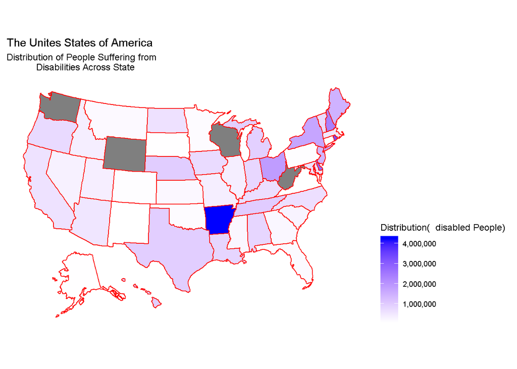

```r
#code starts here

# Select the variables needed for the plot
state.dis.count <-state.dis.count %>%
  select (state.chrcode,count)

# Rename the variables as needed
colnames(state.dis.count) <- c("state", "count")

#plot the distribution on the USA map
plot_usmap(data = state.dis.count, values = "count", color = "red") +
  labs(title = "The Unites States of America",
       subtitle = "Distribution of People Suffering from
           Disabilities Across State")+
  scale_fill_continuous(
    low = "white", high = "blue",
    name = "Distribution(  disabled People) ",
    label = scales::comma ) +
  theme(legend.position = "right")
```

```r
# remove the temporary dataset created
rm(state.dis.count)
```

*Disability Spread by Gender*

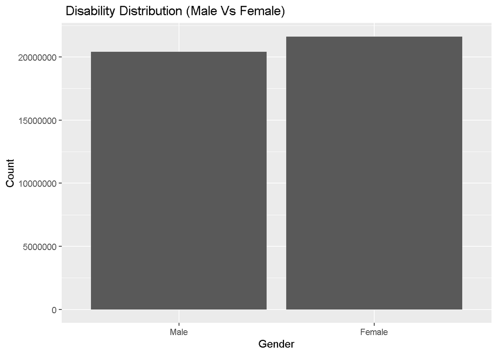

```r
#plot the disability spread for the male and female gende

person.df %>%  group_by(gender) %>%
  summarise(person.count = sum(person.weight))%>%
  ggplot(aes(gender, person.count, dis.status)) +
  geom_bar(stat = "identity") +
  xlab("Gender")+
  ylab("Count")+
  theme(legend.position="none")+
  ggtitle(" Disability Distribution (Male Vs Female)")
```

From the graph it is clear that the male and female populations are both equally impacted by disabilities.

*Disability distribution by Disability type*

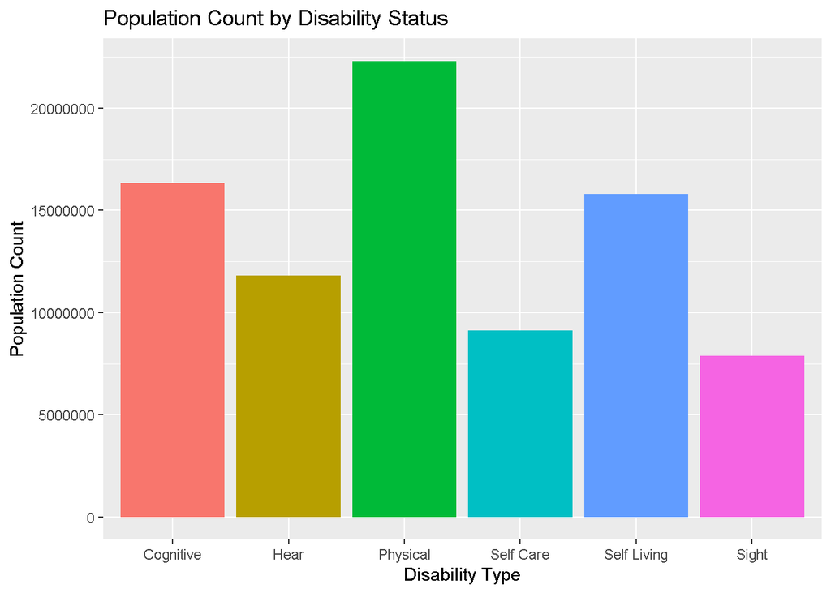

```r
#code starts here

# Conoslidate disability records in one column
# Create a new column by concatenating disability name with its status

disable.df <- person.df %>%
  gather(key = "dis.name",value = "dis.YN",
         dis.selfCare,dis.hear,dis.sight,
         dis.selfLiving,dis.physical,dis.cognitive)%>%
  mutate (disName.status = str_c(dis.name, "_", dis.YN))

# create the bar chart
disable.df %>%
  filter(dis.YN =="Yes" ) %>%
  group_by(disName.status) %>%
  summarise(person.count = sum(person.weight))%>%
  ggplot(aes(disName.status, person.count, fill=disName.status)) +
  geom_bar(stat = "identity") +
  xlab("Disability Type")+
  ylab("Population Count")+
  theme(legend.position="none")+
  ggtitle("Population Count by Disability Status") +
  scale_x_discrete(labels=c("dis.selfCare_Yes" = "Self Care",
                            "dis.hear_Yes" = "Hear",
                            "dis.sight_Yes" = "Sight",
                            "dis.selfLiving_Yes" = "Self Living",
                            "dis.physical_Yes" = "Physical",
                            "dis.cognitive_Yes" = "Cognitive"))
```

It is clear that the population of people suffering from physical disabilites is highest. However, population in other categories is also substantial.

*Disability Distribution by Age*

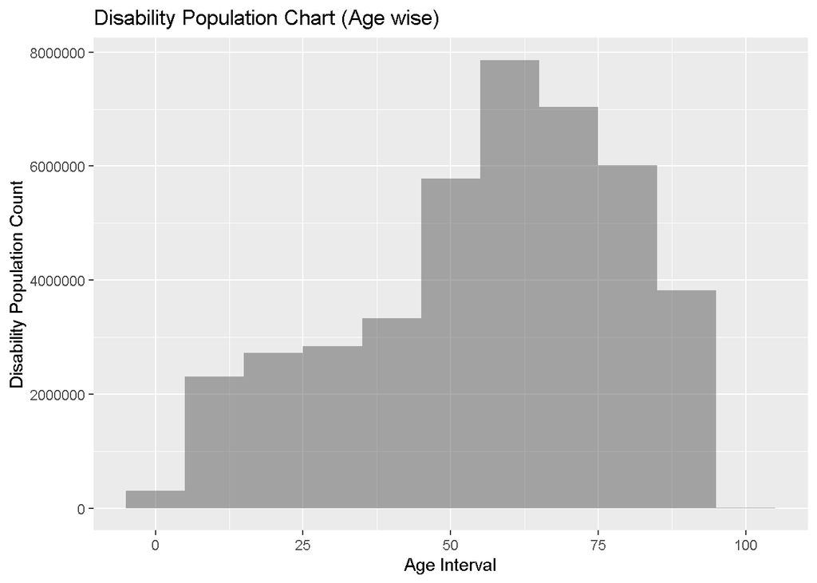

```r
#check the age distribution
ggplot(person.df, aes(x=age, weights = person.weight)) +
  geom_histogram(binwidth=10, alpha=1/2)+
  xlab("Age Interval")+
  ylab("Disability Population Count")+
  ggtitle("Disability Population Chart (Age wise)")+
  theme(legend.position="none")
```

- First, in the lower age category only children who have disability by birth will be present. So the count is very low.
- During old age, people develop self care, hearing, sight and physical (accidental or age related) disabilities. Hence, the number is higher in this age range.
- The overall population after 85 is usually low in any country. This explains the smaller number in categories above the age of 85.

Once the sample dataset is finalized. A Q-Q plot can give better insight into age distribution.

# Methodology

This section focuses on understanding data discrepancies and inconsistencies such as missing data, outliers, and the impact of income adjustment factors and person weights on the data.

## Missing data issue

The microdata provided by ACS has many missing values. However, not all of the records that have missing values can be considered to be faulty data. Some of the missing values could be due to design. For example, the income of a five year old child. An in-depth analysis can help in finding the scenarios where records having missing values need to be discarded or kept.

It is important to have a look at the missing values present in the dataset.

```r
# get the missing values count and transpose
missingValues <- person.df %>%
  summarise_all(funs(sum(is.na(.)))) %>%
  t()

# rename the column, sort and display the result

colnames(missingValues) <- c("Missing.Value.Count" )

missingValues
```

```
##                  Missing.Value.Count
## division                           0
## state.code                         0
## person.weight                      0
## age                                0
## us.citizen                         0
## dis.selfCare                    5519
## dis.hear                           0
## dis.sight                          0
## dis.selfLiving                109011
## dis.physical                    5519
## dis.cognitive                   5519
## English                      2029501
## inc.interest                  109011
## inc.other                     109011
## inc.retire                    109011
## education                          0
## inc.self                      109011
## gender                             0
## inc.salary                    109011
## dis.status                         0
## inc.total                     109011
## inc.adjust                         0
## dis.score                          0
## inc.interest.adj              109011
## inc.other.adj                 109011
## inc.retire.adj                109011
## inc.self.adj                  109011
## inc.salary.adj                109011
## inc.total.adj                 109011
```

*Observation* It seems there are many variables with missing values. However, most of these are either income variables (starting with “inc”) or disability variables (starting with “dis”). One reason for these missing values can be that these values are not applicable for children. Hence, the adult population data needs to be extracted and examined.

```r
# find out the missing values for adult population

missingValues <- person.df %>%
  filter(age > 18)%>%
  summarise_all(funs(sum(is.na(.)))) %>%
  t()

# rename the column, sort and display the result
colnames(missingValues) <- c("Missing.Value.Count" )

#Check the missing value record
missingValues[!(missingValues ==0)]
```

```
## [1] 1886723
```

There are no missing values for the adult population except in one case. This variable can be examined at the time of analysis. Hence no special handling of missing values is required in this project.

## Weights Adjustments

AS “THE PUBLIC USE MICRODATA SAMPLE (PUMS)” datasets used in the project have been created using a data unit called PUMA ( Public Use Microdata Area), each record in this dataset is a group of people selected from a specific area. The total number of people selected are stored in the “weight” variable whereas the record contains the average of the people in that group. Thus the numeric variables need to be multiplied by the weight in order to get the actual values, whereas for categorical variables the sum of the weights should be taken instead of the count. This adds to the complexity of the task. Standard statistical tools may not give accurate results in few situations.

While this behavior would definitely impact the summary variables such as the mean and the median, its impact on the absolute ratio type statistics such as standard deviation, variance and root mean square errors, needs to be checked. The graphical distribution of the data may not experience any other impact apart from an increase in the magnitude of the quantity. However, that also will depend on the type of plotting.

The code below checks the impact of weight on basic statistical measures.

*Categorical Variables*

```r
# code starts here
# Sum up the number of records for disabilities

#hearing disabilties
hear <-  person.df %>%
  group_by (dis.hear) %>%
  summarise ( count.hear = sum(person.weight))

#Sight disabilties
sight <-  person.df %>%
  group_by (dis.sight) %>%
  summarise ( count.sight = sum(person.weight))

#get the total disability status and join with the other disabilties

person.df %>% group_by (dis.status)%>%
  summarise ( count.dis = sum(person.weight))%>%
  inner_join (hear, by = c("dis.status" = "dis.hear")) %>%
  inner_join(sight,by = c("dis.status" = "dis.sight"))
```

| dis.status | count.dis | count.hear | count.sight |
| --- | --- | --- | --- |
| Yes | 42039514 | 11801376 | 7863278 |

```r
# count the number of records for disabilities

person.df %>% select (dis.status,dis.hear, dis.sight) %>%
  sapply(table) %>% t()
```

```
##      dis.status dis.hear  dis.sight
## [1,] 2341548    Integer,2 Integer,2
```

As observed from both the tables, there is considerable difference between the number of records and the total number of people for different categorical variables. It is better to consider number of people instead of the count of records when doing various statistical tests as the weight may impact results.

*Continuous Variable*

```r
# calcualte the mean and variance without weights and with weights

person.df %>% summarise(inc.mean = mean(inc.total.adj,na.rm = TRUE ),
                        inc.wght.mean = wtd.mean (inc.total.adj,
                                                  na.rm = TRUE,weights =person.weight),
                        inc.var = var(inc.total.adj,na.rm = TRUE),
                        inc.wght.var = wtd.var(inc.total.adj,na.rm = TRUE,
                                               weights =person.weight))
```

| inc.mean | inc.wght.mean | inc.var | inc.wght.var |
| --- | --- | --- | --- |
| 254593 | 250976 | 151906782340 | 146399096569 |

It is clear that there is difference in the mean and the variance of the total income when the count of people is taken into account. So the best way is to take the weighted values while performing statistical tests. Even the percentage may vary as weights are uneven for different records. Another alternative option is to generate two statistical models, one with weights and another without weights, and then compare the results.

For this project, weighted values are used.

## Top Coded and Bottom Coded Values

Several variables selected for income analysis are top and/or bottom coded in ACS survey. The list of coded fields that are used in this project is given below:

AGEP - Age (Top Coded) OIP - All other income past 12 months(Top Coded) RETP - Retirement income past 12 months (Top Coded) WAGP - Wages or salary income past 12 months(Top Coded) INTP - Interest, dividend and net rental income pass 12 months(Top & Bottom Coded) SEMP - Self-employment income past 12 months (Top & Bottom Coded)

The values for top coded and bottom coded variables are derived based on the following rules:

1. Age and all base dollar amounts are top coded using the state mean of all cases greater than or equal to the top-coded state threshold value.
2. Income variables that can have negative values (Self-employment Income, or SEMP, and Interest, Dividends, and Net Rental Income, or INTP) are bottom coded using the state mean of all cases less than or equal to the bottom-coded state threshold value.

The top coded and bottom coded values may impact the analysis considerably depending on the sample selected.

```r
#Code here

# Read the statewise top coded and bottom code values
codedval.rec <-read.csv("2018_pums_top_and_bottom_coded_values.csv")

# get a glimpse of data struture
str(codedval.rec)
```

```
## 'data.frame':    52 obs. of  54 variables:
##  $ BST     : int  1 2 4 5 6 8 9 10 11 12 ...
##  $ STATE   : Factor w/ 52 levels "AK","AL","AR",..: 2 1 4 3 5 6 7 9 8 10 ...
##  $ ELETPCT : int  550 520 550 500 600 430 600 500 500 500 ...
##  $ T_ELE   : int  620 590 610 550 650 520 650 560 540 560 ...
##  $ GASTPCT : int  390 420 300 390 320 320 500 460 350 170 ...
##  $ T_GAS   : int  480 520 400 490 450 460 570 530 440 290 ...
##  $ WATTPCT : int  2400 2800 3200 2400 3600 2600 2400 2400 2500 2600 ...
##  $ T_WAT   : int  3100 3400 3800 3100 4100 3300 3100 2800 3600 3400 ...
##  $ FULTPCT : int  2700 5400 1900 2000 2000 1700 4600 3000 3700 2400 ...
##  $ T_FUL   : int  3900 7100 2800 3300 2900 2400 5700 3500 4300 3600 ...
##  $ CONTPCT : int  1000 560 600 770 920 680 760 700 1400 1200 ...
##  $ T_CON   : int  1100 690 1000 870 1200 920 940 950 1400 1400 ...
##  $ RNTTPCT : int  1700 2400 2300 1500 3700 2800 3000 2100 3800 2800 ...
##  $ T_RNT   : int  2400 2800 2900 2000 3900 3200 3300 2800 3900 3300 ...
```

[output cut: 40 more lines]

```r
#Append state code to the top coded and bottom coded file and select
# the relvant fields.Use state dataset generated previously

codedval.df <-codedval.rec %>%
  inner_join(state.df, by = c("BST" = "state.numcode") )%>%
  select(BST,state.chrcode,state.name,T_WAG,T_SEM,B_SEM,B_INT,
         T_INT,T_RET,T_OI,T_AGE)

#Rename the variables

colnames(codedval.df) <- c("state.numcode","state.chrcode", "state.name" ,
                           "top.inc.salary","top.inc.self", "btm.inc.self",
                           "btm.inc.interest","top.inc.interest",
                           "top.inc.retire", "top.inc.other", "top.age" )
# Count the number of rows

state.no <- nrow(codedval.df)
paste ("Total number of top coded or bottom coded records:",state.no)
```

```
## [1] "Total number of top coded or bottom coded records: 52"
```

The file has records for 52 states. There is no missing value in the data. Now the records are extracted from the sample dataset which has top coded or bottom coded values.

```r
# code start here

#  the  sample for adult population having one disability

inc.sample <- person.df %>%
  mutate ( state.numeric_temp = as.numeric(state.code)) %>%
  inner_join(codedval.df, by = c("state.numeric_temp" = "state.numcode"))%>%
  mutate(state.chrcode = as.factor(state.chrcode)) %>%
  filter(dis.score ==1)%>%
  filter (age >=18)

#  the  sample for adult population having one disability and
#no top coded or bottom coded values

inc.sample.nocodedvalue <- inc.sample %>%
  filter(!(top.inc.salary == inc.salary) |
           (top.inc.self == inc.self)|
           (btm.inc.self == inc.self)|
           (btm.inc.interest ==inc.interest) |
           (top.inc.interest == inc.interest)|
           (top.inc.retire ==inc.retire) |
           (top.inc.other ==inc.other))

#print the total no of records

paste ("Total Records in the sample dataset :",nrow(inc.sample))
```

```
## [1] "Total Records in the sample dataset : 954462"
```

```r
# print the total number of records
paste ("Total records after removing top coded and bottom coded values : " ,
       nrow(inc.sample.nocodedvalue))
```

```
## [1] "Total records after removing top coded and bottom coded values :  954462"
```

There is no top coded or bottom coded record in the sample data.

## Income Adjustment Factor

Since this survey was spread over five years, ACS has given an adjustment factor to adjust the income for inflation. The income variables must be multiplied with the adjustment factor to get the actual income of a person. An analysis without considering the adjustment factor may impact the results of statistical tests. One simple check is to calculate the difference in the standard statistical parameters like the mean and the variance due to income adjustment.

```r
# the mean and the variance with adjustment

inc.sample %>% summarise( inc.adj.mean = wtd.mean (inc.total.adj,na.rm = TRUE,
                                                   weights =person.weight),
                          inc.adj.var = wtd.var(inc.total.adj,na.rm = TRUE,
                                                weights =person.weight))
```

| inc.adj.mean | inc.adj.var |
| --- | --- |
| 304737 | 197252012362 |

```r
# mean and variance without adjustment

inc.sample %>% summarise( inc.mean = wtd.mean (inc.total,na.rm = TRUE,
                                               weights =person.weight),
                          inc.var = wtd.var(inc.total,na.rm = TRUE,
                                            weights =person.weight))
```

| inc.mean | inc.var |
| --- | --- |
| 29423 | 1841681499 |

There is a difference in the mean and variance of the adjusted and the unadjusted incomes. So either only adjusted values should be taken, or both samples should be analysed and then compared. For this project, adjusted values are used for all statistical analysis.

## Outliers

An outlier is an observation which stands far away from most of the other observations. An outlier may or may not be due to measurement errors. Therefore, one of the most important task in data analysis is to identify and (if necessary) remove the outliers.

There are two continuous variables, income and age, in the dataset which need to examined closely for outliers.

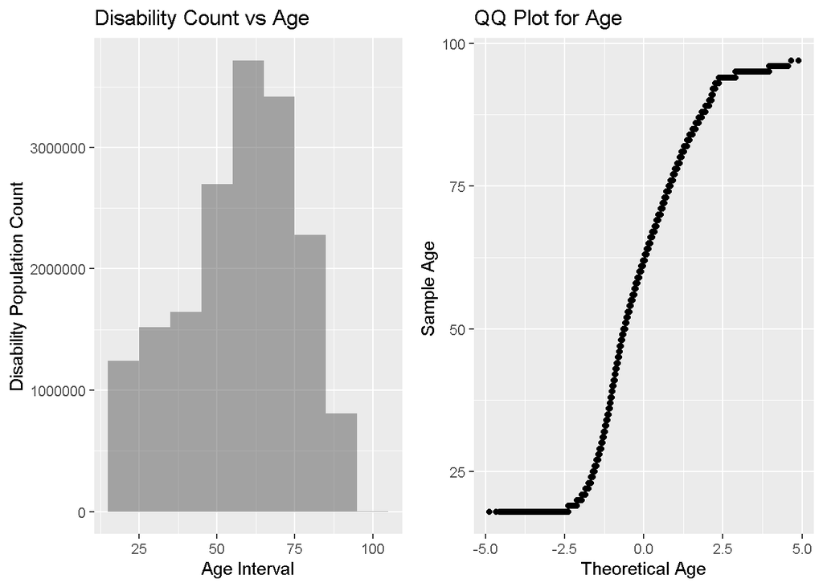

```r
# check the age distribution
age.plot <- ggplot(inc.sample, aes(x=age, weights = person.weight)) +
  geom_histogram(binwidth=10, alpha=1/2)+
  xlab("Age Interval")+
  ylab("Disability Population Count")+
  ggtitle("Disability Count vs Age ")+
  theme(legend.position="none")

#Create qq-plot
age.qplot <-ggplot(inc.sample, aes(sample=age,weights = person.weight ))+
  stat_qq()+
  ggtitle("QQ Plot for Age")+
  theme(legend.position="none")+
  xlab("Theoretical Age")+
  ylab("Sample Age ")

# arrange the plots in a grid
grid.arrange(age.plot,age.qplot, ncol=2 )
```

*Outliers in the Income Data*

Since the income of a person depends on many factors, this variable is highly susceptible to uneven distribution. The histogram for the income is generated below.

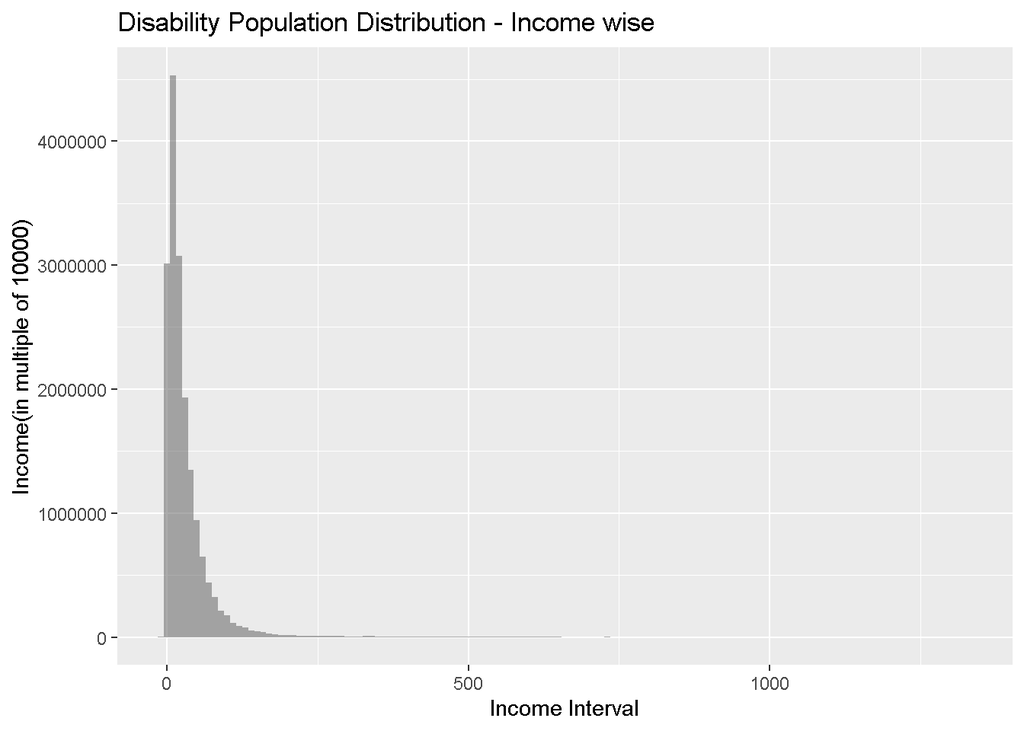

```r
#The income variable here is divided by 10000 to get better insight
ggplot(inc.sample, aes(x=inc.total.adj/10000, weights = person.weight)) +
  geom_histogram(binwidth=10, alpha=1/2)+
  xlab("Income Interval")+
  ylab("Income(in multiple of 10000)")+
  ggtitle("Disability Population Distribution - Income wise")+
  theme(legend.position="none")
```

This chart shows that there is a very small group of people in the high income range. However the curve on the right side starts at high income. This may be due the fact that the population considered here is the adult population. Their salary increases till the age of retirement and then drops drastically after that.

## Concluding Remark

Initial thought process was to understand the status of the people suffering disabilities in life in the USA. The idea was to know the difference between the income of the people with disabilities and without disabilites. However as the project progressed, that particular analysis looked very straight forward as it is very well known that disabled people usually do not get the same kind of opportunities as people with no disabilities. So instead, it was decided to compare the income of the people having different disabilities within themselves. During this process, focus will also be on identifying the factors that determine the income of the people facing disabilities.

There are a few assumptions which are made in this project. Firstly, the sample surveyed is a random sample and secondly, the sample is from the population which has same disability distribution division wise, age wise and gender wise. The statistical tests to verify these assumptions could not be performed as the required population statistics were not available.

# Findings

This section covers the detailed analysis performed on the sample dataset to identify the factors that influences the income of people suffering from disabilities.

## Overview

The income of a person depends on a large number of parameters. Attributes may vary from the age and education of a person to the availability of an opportunity at right time or family conditions. This situation may be different for a disabled person as they have extra constraints. Some favors that can be looked at are age, gender, State of residence, disability type, and education.

Further the income may also be influenced by other factors like the number of disabilites, their English speaking capability and their citizenship status. While it would not be possible to identify all biases, it was ensured that the sample data consists of only people who

- have only one disability,
- are adults
- have no top coded or bottom coded values
- have income adjusted for inflation

The initial sample dataset created in methodology section can be taken as the input for this analysis.

## Statistical Methods Selection

As there are more than two factors to be analysed and there are six disability types, it is not possible to use linear regression or t-test. Two major analysis that can be used are - Anova analysis to understand the difference between incomes, and multiple regression for identifying influencing factors.

### Anova Analysis

The null hypothesis here is that there is no significant difference among the income of people with different disabilities. ‘avov’ function can be used to do the statisticial testing.

The first step is to examine the data graphically.

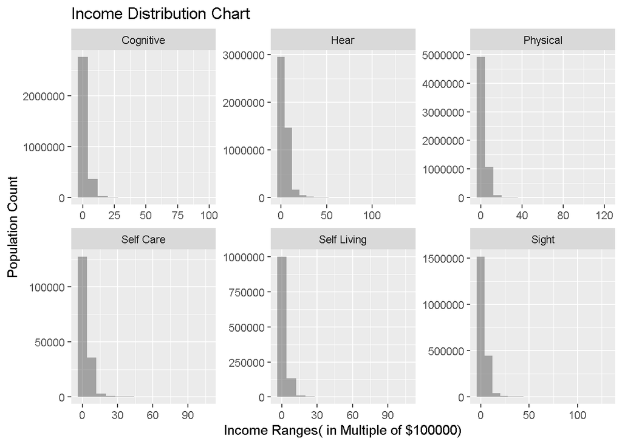

```r
# Inspect the data graphically
# Gather the data so that disabilities are consolidated in one column.
# Filter all the records which have no disabilities.

inc.dis.row <- inc.sample %>%
  select(dis.selfCare,dis.hear,dis.sight,
         dis.selfLiving,dis.physical,dis.cognitive,
         inc.total.adj,person.weight) %>%
  gather(key = "dis.name",value = "dis.YN",
         dis.selfCare, dis.hear, dis.sight,
         dis.selfLiving, dis.physical,
         dis.cognitive )%>%
  filter(dis.YN =="Yes") %>%
  mutate ( dis.name = fct_recode(as.factor(dis.name),
                                 "Self Care" ="dis.selfCare",
                                 "Hear" = "dis.hear" ,
                                 "Sight" = "dis.sight" ,
                                 "Self Living" = "dis.selfLiving",
                                 "Physical" = "dis.physical" ,
                                 "Cognitive" = "dis.cognitive" ))


#plot the income distribution chart for each disabilities

inc.dis.row %>%
  ggplot(aes(inc.total.adj/100000,weight = person.weight)) +
  facet_wrap(~dis.name, scale="free") +
  geom_histogram(binwidth=8, alpha=1/2)+
  ggtitle("Income Distribution Chart") +
  xlab("Income Ranges( in Multiple of $100000)") +
  ylab("Population Count")
```

Although the distribution pattern is same for all the disabilities, incomes are different for the people having different disabilities. A statistical test must be used to find if there is a significant difference in the incomes.

```r
# code Starts
# implement the weight factor

inc.dis.row <- inc.dis.row%>%
  mutate(inc.weight.adj = inc.total.adj*person.weight)

#Generate the Anove(Aov model)

inc.aov <- aov(inc.weight.adj ~ dis.name  - 1, inc.dis.row)
inc.aov.intercept <- aov(inc.weight.adj ~ dis.name, inc.dis.row)

#print the summary
summary(inc.aov)
```

```
##               Df               Sum Sq             Mean Sq F value
## dis.name       6 31045643669616816128 5174273944936135680   49621
## Residuals 954456 99527548001161461760     104276727267848
##                        Pr(>F)
## dis.name  <0.0000000000000002 ***
## Residuals
## ---
## Signif. codes:  0 '***' 0.001 '**' 0.01 '*' 0.05 '.' 0.1 ' ' 1
```

As the p-value is less than 0.05, it is clear that at 5% level of significance, there are evidences that a significant difference exists in the incomes of people suffering from different disabilities. The difference between the groups can be checked by making a plot of the group means and confidence intervals.

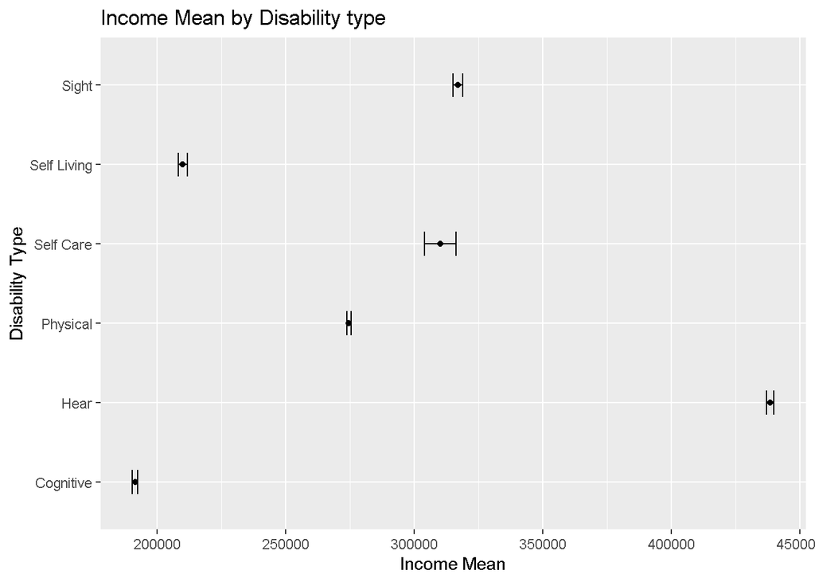

```r
#code starts here
# Plot the confidence Interval
inc.dis.row %>% group_by(dis.name) %>%
  summarise(dis.mean=weighted.mean(x= inc.total.adj, w=person.weight),
            dis.sd=sqrt(wtd.var(x=inc.total.adj,w=person.weight)),
            Length=NROW(inc.total.adj),
            tfrac=qt(p=.90, df=Length-1),
            Lower=dis.mean - tfrac*dis.sd/sqrt(Length),
            Upper=dis.mean + tfrac*dis.sd/sqrt(Length)
  ) %>%
  ggplot(aes(x=dis.mean, y=dis.name)) + geom_point() +
  geom_errorbarh(aes(xmin=Lower, xmax=Upper), height=.3) +
  scale_y_discrete(labels=c("dis.selfCare" = "Self Care",
                            "dis.hear" = "Hear",
                            "dis.sight" = "Sight",
                            "dis.selfLiving" = "Self Living",
                            "dis.physical" = "Physical",
                            "dis.cognitive" = "Cognitive"))+
  ggtitle("Income Mean by Disability type") +
  xlab("Income Mean") +
  ylab("Disability Type")
```

This shows there is significant difference in the average income of people suffering from different disabilities.

There can be many factors leading to this result such as

1. Education level
2. State or Division of residence
3. Gender
4. Age
5. Citizenship status
6. Disability type

### Multiple Regression Model

Multiple regression analysis is a technique used to fit a model to predict the unknown value of a variable from the known value of two or more variables that are also called the predictors. Multiple regression assumes that there is a linear relationship between the dependent variable and the predictors. It can be used for categorical variables also.

Before the analysis, it is important to examine the relationship between the variables.

*Citizenship status*

A table is created to store the count of people with US and Non-US citizenship.

```r
#Code starts here

#create a new dataset with the predictor variables selected

inc.reg.df <- inc.sample %>%
  select(state.code, state.chrcode,state.name,division,
         gender, age, education,
         us.citizen, dis.score, dis.status,
         dis.selfCare,dis.hear,dis.sight,
         dis.selfLiving,dis.physical,dis.cognitive,
         inc.total.adj,person.weight ) %>%
  mutate (inc.total.adj = inc.total.adj/1000)


# count the number of the people based on citizenship
inc.reg.df %>% group_by (us.citizen) %>%
  summarise (count = sum(person.weight))
```

| us.citizen | count |
| --- | --- |
| US.Citizen | 16610080 |
| Non.US.citizen | 712390 |

This clearly indicates that there is a small number of the people who are not US citizens. This may lead to high variance during statistical analysis of the income data. Hence, these records are dropped from the sample.

```r
# filter the non US citizen record
inc.reg.df <- inc.reg.df  %>% filter(us.citizen == "US.Citizen")
```

*Age* Age is an important factor which can impact the income. A scatter plot can be used to examine the data visually.

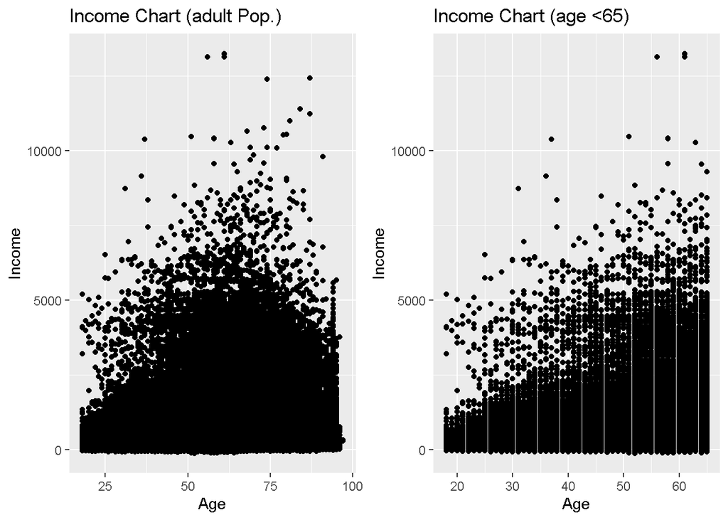

```r
# plot the graph for age

age.all <-ggplot(inc.reg.df, aes(x = age, y = inc.total.adj,
                                 weights = person.weight)) +
  geom_point() +
  ggtitle("Income Chart (adult Pop.)") +
  xlab("Age") +
  ylab("Income")

#filter the records for age <=65

inc.reg.df <- inc.reg.df %>%
  filter(age <=65)

#create a box plot for the people having age <=65
age.below65 <- ggplot(inc.reg.df, aes(x = age, y = inc.total.adj,
                                      weights = person.weight)) +
  geom_point() +
  ggtitle("Income Chart (age <65)") +
  xlab("Age") +
  ylab("Income")

# arrange the plot in a grid
grid.arrange(age.all,age.below65, ncol =2 )
```

From the chart it is clear that although there is a pattern that the income increases with age, there is a large variation in the income. It is also very clear that at the later stages of life, income suddenly drops. This seems reasonable as the income decreases after retirement age. Thus, records below the age of 65 can be used for analysis.

*Correlation Computation*

```r
# find out the correlation

with (inc.reg.df,wtd.cor(age,inc.total.adj,weight=person.weight,mean1=FALSE))
```

```
##   correlation   std.err t.value p.value
## Y     0.17641 0.0013464  131.02       0
```

This shows a positive linear relationship between the age and the income. Test statistics (=0.17) indicate a weak association. Since the p-value is < 0.05, the age is a strong candidate for use in multiple regression analysis.

*Education*

Education is always considered an important factor in determining the income of a person. Although education is a categorical variable, the situation is tricky here as it has as many levels as 24. It is a good idea to plot the points on a scatter plot to see the spread.

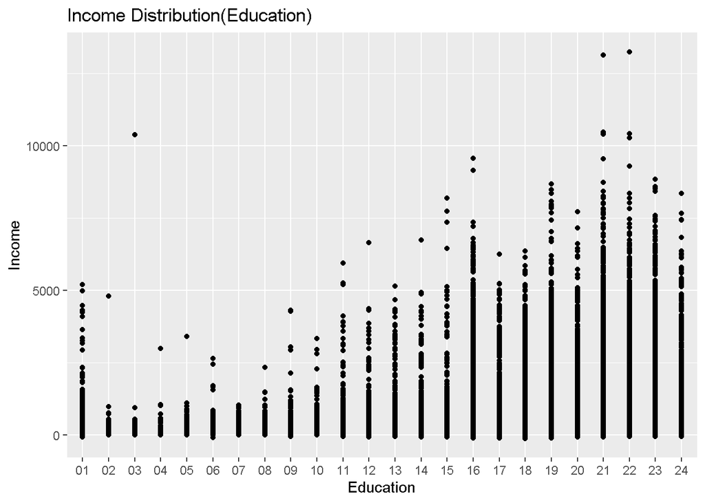

```r
ggplot(inc.reg.df, aes(x = education, y = inc.total.adj, weights = person.weight)) +
  geom_point() +
  ggtitle("Income Distribution(Education)") +
  xlab("Education") +
  ylab("Income")
```

This shows that the income varies at each level. Further, the income is lower at the doctoral level. This could be because people with doctorate degree usually work in education institutes where salaries are not as high as in corporate world. Further there is a very sporadic behavior for education at level 01. These are people who have reported no schooling. Anova analysis can be done to test the significance of the education variables.

```r
# Conslidate the total income

inc.reg.df <- inc.reg.df%>%
  mutate(inc.weight.adj = inc.total.adj*person.weight)

#Generate the Anov(aov model)

inc.aov <- aov(inc.weight.adj ~ education  - 1, inc.reg.df)

#print the summary
summary(inc.aov)
```

```
##               Df         Sum Sq      Mean Sq F value              Pr(>F)
## education     24 20771106910568 865462787940    7906 <0.0000000000000002
## Residuals 534435 58504464679843    109469748
##
## education ***
## Residuals
## ---
## Signif. codes:  0 '***' 0.001 '**' 0.01 '*' 0.05 '.' 0.1 ' ' 1
```

There is significant difference between the income of the people having different level of education. So education will also be considered for multiple regression analysis.

*Disability type Analysis*

The initial graph reported a large number of outliers in the boxplot as shown below in the chart.

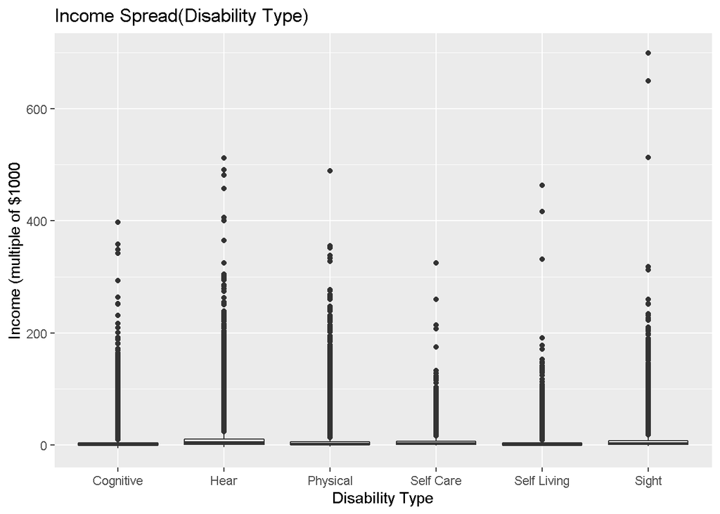

```r
# Boxplots showing per person income broken down by disability type

inc.reg.df %>%  gather(key = "dis.name",value = "dis.YN",
                       dis.selfCare,dis.hear,dis.sight,dis.selfLiving,
                       dis.physical,dis.cognitive)%>%
  filter(dis.YN =="Yes") %>%
  ggplot(aes(x = dis.name, y = inc.weight.adj/1000)) +
  geom_boxplot() +
  ggtitle("Income Spread(Disability Type)") +
  xlab("Disability Type") +
  ylab("Income (multiple of $1000")+
  scale_x_discrete(labels=c("dis.selfCare" = "Self Care",
                            "dis.hear" = "Hear",
                            "dis.sight" = "Sight",
                            "dis.selfLiving" = "Self Living",
                            "dis.physical" = "Physical",
                            "dis.cognitive" = "Cognitive"))
```

However outlier records cannot be dropped randomly. Instead, two datasets were created- one with outliers and another without outlier. The analysis was performed on both the records to understand the difference.

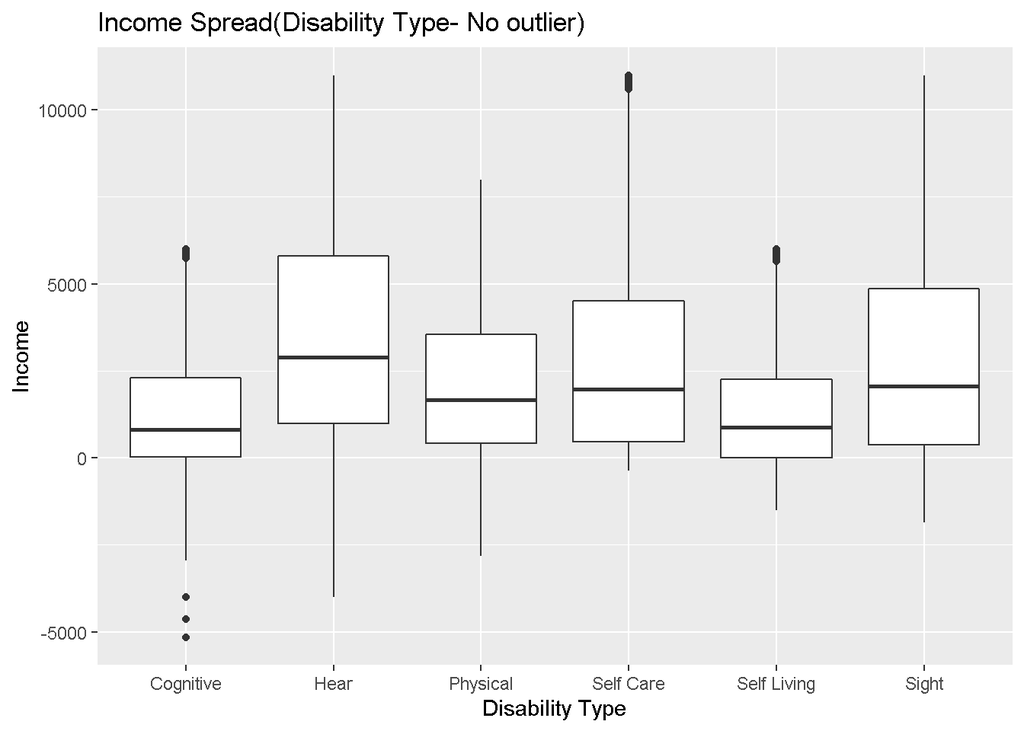

```r
#Create dataset with no outliers.

inc.noout  <-   inc.reg.df %>%
  filter ( inc.weight.adj < 11000) %>%
  filter(!(dis.cognitive =="Yes" & inc.weight.adj > 6000)) %>%
  filter(!(dis.physical =="Yes" & inc.weight.adj > 8000)) %>%
  filter(!(dis.selfLiving =="Yes" & inc.weight.adj >6000))


# Boxplots showing the income broken down by disability type with no outlier.
inc.noout %>%  gather(key = "dis.name",value = "dis.YN",
                      dis.selfCare,dis.hear,
                      dis.sight,dis.selfLiving,
                      dis.physical,dis.cognitive)%>%
  filter(dis.YN =="Yes") %>%
  ggplot(aes(x = dis.name, y = inc.weight.adj)) +
  geom_boxplot()+
  ggtitle("Income Spread(Disability Type- No outlier)") +
  xlab("Disability Type") +
  ylab("Income") +
  scale_x_discrete(labels=c("dis.selfCare" = "Self Care",
                            "dis.hear" = "Hear",
                            "dis.sight" = "Sight",
                            "dis.selfLiving" = "Self Living",
                            "dis.physical" = "Physical",
                            "dis.cognitive" = "Cognitive"))
```

*Gender* This is another variable which was explored for an impact on income. Initial analysis indicates outliers in the data. However once the data is filtered for disability types, the outliers are very small in number and can be ignored.

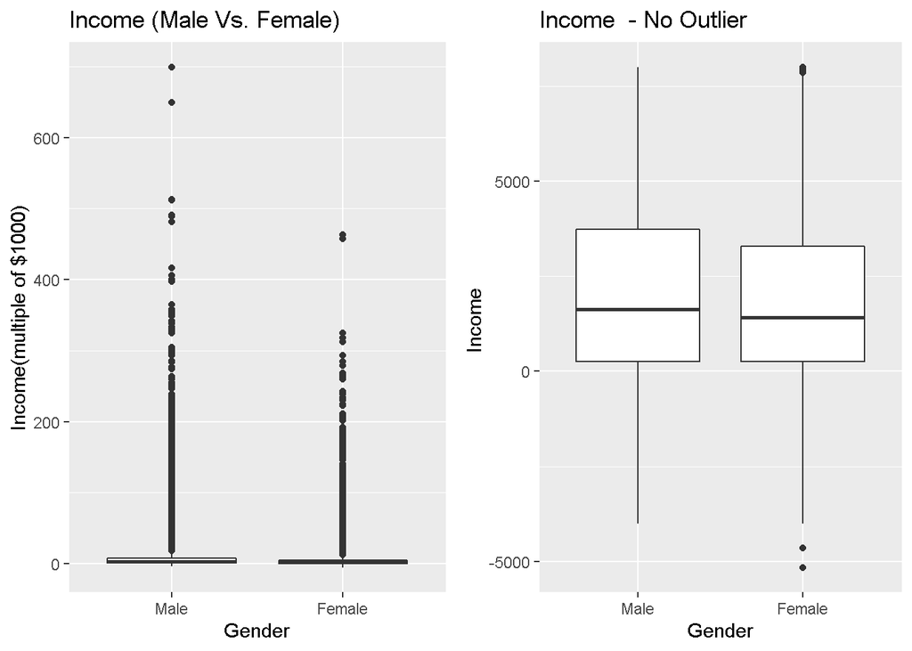

```r
# Income distribution by Gender

#plot the income with outlier records included

inc.plot.all <- inc.reg.df %>%
  ggplot( aes(x = gender, y = inc.weight.adj/1000)) +
  geom_boxplot()+
  ggtitle("Income (Male Vs. Female)") +
  xlab("Gender") +
  ylab("Income(multiple of $1000)")

# dataset with no outlier. The thrashhold vauel has been choosen by hit and trail method
inc.noout  <-   inc.reg.df %>%
  filter ( inc.weight.adj < 8000)

#plot the income with outliers excluded
inc.plot.noout <- ggplot( inc.noout, aes(x = gender, y =inc.weight.adj)) +
  geom_boxplot()+
  ggtitle("Income  - No Outlier")  +
  xlab("Gender") +
  ylab("Income ")

grid.arrange(inc.plot.all,inc.plot.noout, ncol=2)
```

*Division*

The income of a person may also depend on the economy of the division or state in which the person resides. Again the plots are analysed for both datasets.

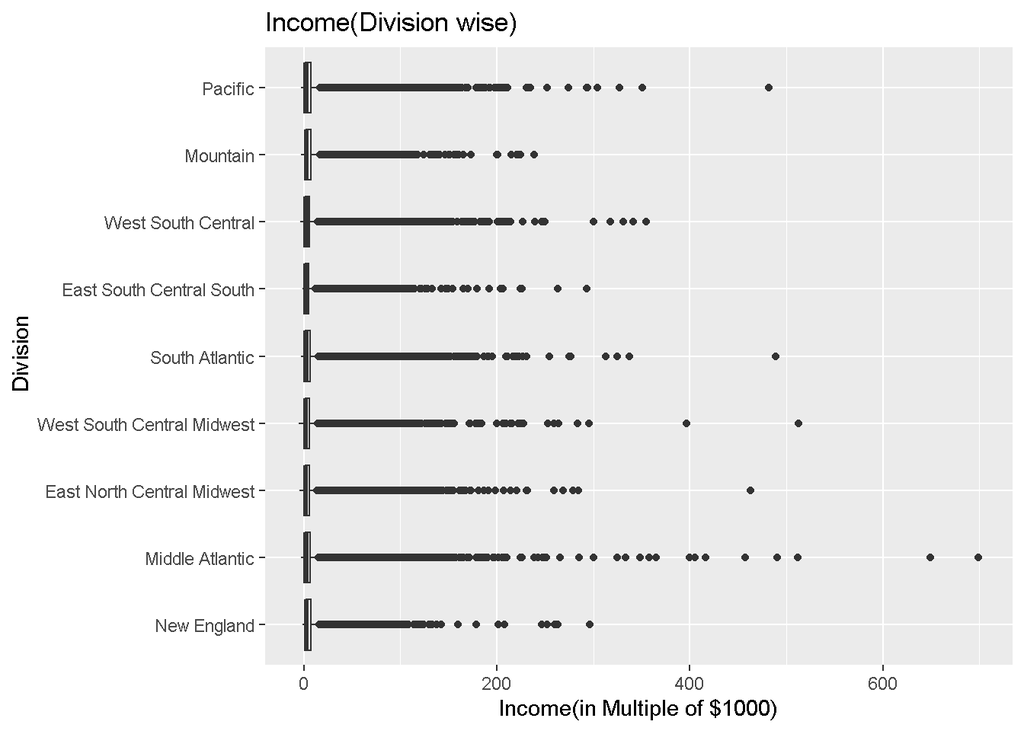

```r
#plot the income with outlier records included

inc.reg.df %>%
  ggplot( aes(x = division, y = inc.weight.adj/1000)) +
  geom_boxplot()+
  ggtitle("Income(Division wise)") +
  xlab(" Division") +
  ylab("Income(in Multiple of $1000)") +
  coord_flip()
```

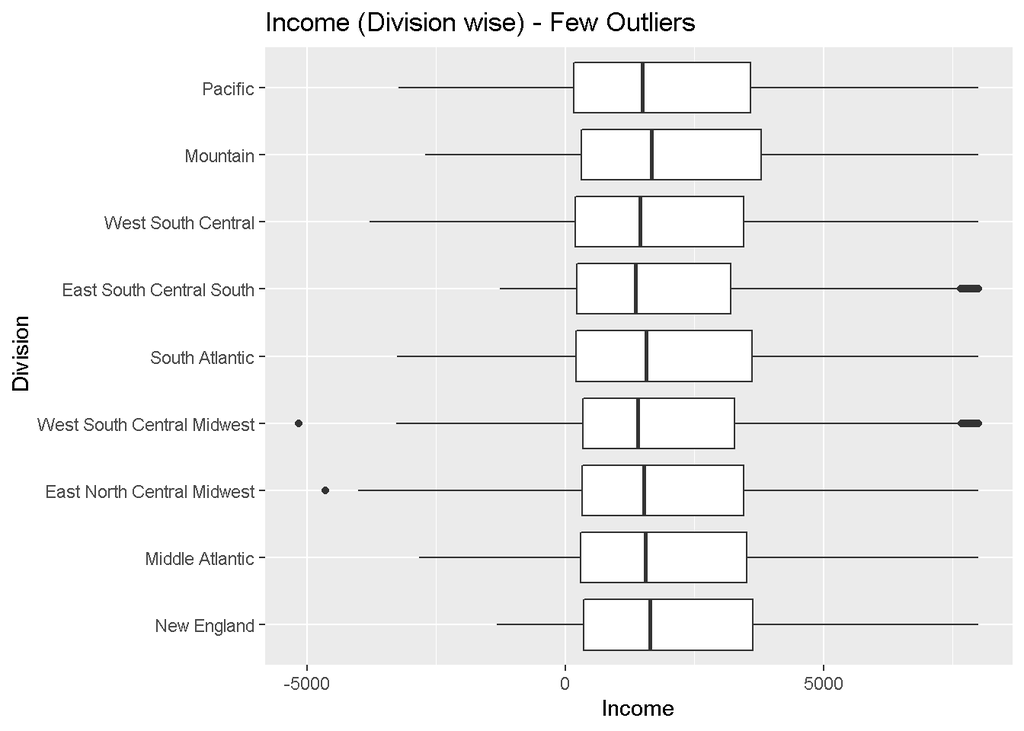

```r
#plot the income with outliers excluded
ggplot( inc.noout, aes(x = division, y = inc.weight.adj)) +
  geom_boxplot()+
  ggtitle("Income (Division wise) - Few Outliers")  +
  xlab(" Division") +
  ylab("Income") +
  coord_flip()
```

The data has outliers. The boxplot after filtering of outliers is given as :

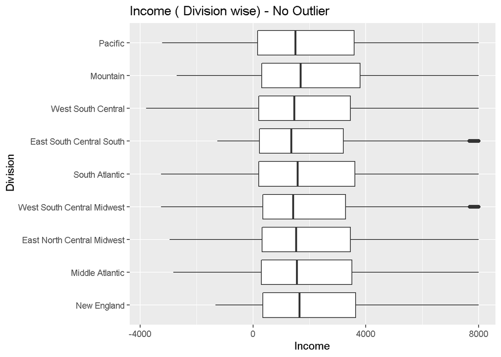

```r
#plot the income with outlier records included


inc.noout  <- inc.noout %>%  filter  (inc.weight.adj > -4000)

inc.noout %>%
#plot the income with outliers excluded
ggplot( aes(x = division, y = inc.weight.adj)) +
  geom_boxplot()+
  ggtitle("Income ( Division wise) - No Outlier")  +
  xlab(" Division") +
  ylab("Income") +
  coord_flip()
```

```r
#Generate the Anov(aov model)

inc.aov <- aov(inc.weight.adj ~ division  - 1, inc.reg.df)

#print the summary
summary(inc.aov)
```

```
##               Df         Sum Sq       Mean Sq F value              Pr(>F)
## division       9 16377565419460 1819729491051   15462 <0.0000000000000002
## Residuals 534450 62898006170949     117687354
##
## division  ***
## Residuals
## ---
## Signif. codes:  0 '***' 0.001 '**' 0.01 '*' 0.05 '.' 0.1 ' ' 1
```

Since the p-value <0.5, there is a significant difference in the income of people residing in different divisions. This variable is also a candidate for the multiple regression model.

**Multiple Regression Analysis**

There are few transformations that need to be applied before starting regression analysis.

*Centralize the age variable*

The intercept calculated during a multiple regression analysis is essentially the expected value of the response variable when predictor variables are zero. In our case, the income for a person have zero does not make any useful interpretation so it is better to centralize the age variable so that average income can be calculated when the mean age is zero.

```r
#Code starts here
# centre the mean age

inc.reg.df <- inc.reg.df %>%
  mutate(age.centre = scale(age, center=TRUE, scale=FALSE))

inc.noout <- inc.noout %>%
  mutate(age.centre = scale(age, center=TRUE, scale=FALSE))
```

*Collapse the education levels*

Education has a large number of factor levels. Since the income across all the education levels before high school is consistent, the factors can be merged. This will help in better comprehensibility of the model.

```r
#Code start here
# Combine education level to get more meaning full data
# also drop unused levels and select the variables which are to be included in the analysis
# group disabiltie levle in one variable

str(inc.reg.df)
```

```
## 'data.frame':    534459 obs. of  20 variables:
##  $ state.code    : Factor w/ 51 levels "01","02","04",..: 1 1 1 1 1 1 1 1 1 1 ...
##  $ state.chrcode : Factor w/ 47 levels "AK","AL","AR",..: 2 2 2 2 2 2 2 2 2 2 ...
##  $ state.name    : chr  "Alabama" "Alabama" "Alabama" "Alabama" ...
##  $ division      : Factor w/ 9 levels "New England",..: 6 6 6 6 6 6 6 6 6 6 ...
##  $ gender        : Factor w/ 2 levels "Male","Female": 2 2 2 1 1 1 2 2 1 1 ...
##  $ age           : num  50 65 40 65 56 57 35 60 59 53 ...
##  $ education     : Factor w/ 25 levels "","01","02","03",..: 12 22 18 17 12 13 20 22 21 18 ...
##  $ us.citizen    : Factor w/ 2 levels "US.Citizen","Non.US.citizen": 1 1 1 1 1 1 1 1 1 1 ...
##  $ dis.score     : num  1 1 1 1 1 1 1 1 1 1 ...
##  $ dis.status    : Factor w/ 1 level "Yes": 1 1 1 1 1 1 1 1 1 1 ...
##  $ dis.selfCare  : Factor w/ 2 levels "No","Yes": 1 1 1 1 1 1 1 1 1 1 ...
##  $ dis.hear      : Factor w/ 2 levels "No","Yes": 2 1 1 2 1 1 1 1 2 1 ...
##  $ dis.sight     : Factor w/ 2 levels "No","Yes": 1 1 1 1 1 1 1 1 1 1 ...
##  $ dis.selfLiving: Factor w/ 2 levels "No","Yes": 1 2 1 1 1 1 2 1 1 1 ...
##  $ dis.physical  : Factor w/ 2 levels "No","Yes": 1 1 1 1 2 2 1 2 1 1 ...
##  $ dis.cognitive : Factor w/ 2 levels "No","Yes": 1 1 2 1 1 1 1 1 1 2 ...
##  $ inc.total.adj : num  0 482 265 255 85 ...
##  $ person.weight : num  2 20 29 24 22 2 19 13 8 13 ...
##  $ inc.weight.adj: num  0 9643 7699 6117 1869 ...
##  $ age.centre    : num [1:534459, 1] 2.31 17.31 -7.69 17.31 8.31 ...
##   ..- attr(*, "scaled:center")= num 47.7
```

```r
inc.reg.set <-  inc.reg.df %>%
  gather(key = "dis.name", value = "dis.YN", dis.selfCare,
         dis.hear,dis.sight,
         dis.selfLiving,dis.physical,dis.cognitive)%>%
  filter (dis.YN == "Yes") %>%
  mutate(education = fct_other(education,keep = c("15","16","17","18","19",
                                                  "20","21","22","23","24")),
         education = fct_collapse(education, "less than High School" = "Other",
                                  "High School" =c("15", "16","17","18","19"),
                                  "Associate" = "20",
                                  "Bachelors" = "21",
                                  "Masters" = "22",
                                  "Professional" = "23",
                                  "Doctorate" = "24")) %>%
  droplevels() %>%
  select(inc.total.adj, gender, age.centre, education,
         dis.name,inc.total.adj,division,person.weight)


inc.noout.set <-  inc.noout %>%
  gather(key = "dis.name",value = "dis.YN",
         dis.selfCare,dis.hear,dis.sight,
         dis.selfLiving,dis.physical,dis.cognitive)%>%
  filter (dis.YN == "Yes") %>%
  mutate(education = fct_other(education,keep = c("15","16","17","18","19",
                                                  "20","21","22","23","24")),
         education = fct_collapse(education, "less than High School" = "Other",
                                  "High School" =c("15", "16","17","18","19"),
                                  "Associate" = "20",
                                  "Bachelors" = "21",
                                  "Masters" = "22",
                                  "Professional" = "23",
                                  "Doctorate")) %>%
  droplevels() %>%
  select(inc.total.adj, gender, age.centre, education,dis.name,
         inc.total.adj,division,person.weight)
```

Multiple regression model can now be generated as given below

```r
#Generate the models

inc.lm <- lm(inc.total.adj~ .,data=inc.reg.set,weight = person.weight)
inc.lm.noout <- lm(inc.total.adj~ .,data=inc.reg.set, weight=person.weight)

#display the summary for dataset containing all records
summary(inc.lm)
```

```
##
## Call:
## lm(formula = inc.total.adj ~ ., data = inc.reg.set, weights = person.weight)
##
## Weighted Residuals:
##    Min     1Q Median     3Q    Max
## -10587   -680   -218    303  62410
##
## Coefficients:
##                                     Estimate Std. Error t value
## (Intercept)                         255.0696     3.0324   84.12
## genderFemale                       -115.6220     1.0840 -106.66
## age.centre                            3.8211     0.0427   89.54
## educationAssociate                   89.9703     1.9748   45.56
## educationBachelors                  246.5400     1.7489  140.97
## educationMasters                    394.5916     2.7357  144.24
## educationProfessional               774.7240     5.7540  134.64
## educationDoctorate                  581.6805     7.2906   79.78
## educationless than High School      -89.5361     1.6107  -55.59
## dis.namedis.hear                    174.8889     1.6752  104.40
## dis.namedis.physical                 24.8277     1.5263   16.27
## dis.namedis.selfCare                 73.1390     5.1406   14.23
## dis.namedis.selfLiving               -6.9486     2.3910   -2.91
## dis.namedis.sight                    95.3697     1.7966   53.08
## divisionMiddle Atlantic               4.1713     3.1157    1.34
## divisionEast North Central Midwest  -24.0301     3.1105   -7.73
## divisionWest South Central Midwest   -6.0769     3.3682   -1.80
## divisionSouth Atlantic              -21.9107     2.9722   -7.37
## divisionEast South Central South    -41.8950     3.5275  -11.88
## divisionWest South Central           -5.4025     3.0977   -1.74
## divisionMountain                    -11.4473     3.5268   -3.25
## divisionPacific                       8.3896     3.0719    2.73
## person.weight                        -0.0929     0.0205   -4.53
##                                                Pr(>|t|)
## (Intercept)                        < 0.0000000000000002 ***
## genderFemale                       < 0.0000000000000002 ***
## age.centre                         < 0.0000000000000002 ***
## educationAssociate                 < 0.0000000000000002 ***
## educationBachelors                 < 0.0000000000000002 ***
## educationMasters                   < 0.0000000000000002 ***
```

[output cut: 8 more lines]

```
## divisionMiddle Atlantic                          0.1806
## divisionEast North Central Midwest    0.000000000000011 ***
## divisionWest South Central Midwest               0.0712 .
## divisionSouth Atlantic                0.000000000000169 ***
## divisionEast South Central South   < 0.0000000000000002 ***
## divisionWest South Central                       0.0812 .
## divisionMountain                                 0.0012 **
## divisionPacific                                  0.0063 **
## person.weight                         0.000005899501015 ***
## ---
## Signif. codes:  0 '***' 0.001 '**' 0.01 '*' 0.05 '.' 0.1 ' ' 1
##
## Residual standard error: 1710 on 534436 degrees of freedom
## Multiple R-squared:  0.19,   Adjusted R-squared:  0.19
## F-statistic: 5.7e+03 on 22 and 534436 DF,  p-value: <0.0000000000000002
```

```r
# Display the summary for dataset with no outlier
summary(inc.lm.noout)
```

```
##
## Call:
## lm(formula = inc.total.adj ~ ., data = inc.reg.set, weights = person.weight)
##
## Weighted Residuals:
##    Min     1Q Median     3Q    Max
## -10587   -680   -218    303  62410
##
## Coefficients:
##                                     Estimate Std. Error t value
## (Intercept)                         255.0696     3.0324   84.12
## genderFemale                       -115.6220     1.0840 -106.66
## age.centre                            3.8211     0.0427   89.54
## educationAssociate                   89.9703     1.9748   45.56
## educationBachelors                  246.5400     1.7489  140.97
## educationMasters                    394.5916     2.7357  144.24
## educationProfessional               774.7240     5.7540  134.64
## educationDoctorate                  581.6805     7.2906   79.78
## educationless than High School      -89.5361     1.6107  -55.59
## dis.namedis.hear                    174.8889     1.6752  104.40
## dis.namedis.physical                 24.8277     1.5263   16.27
## dis.namedis.selfCare                 73.1390     5.1406   14.23
## dis.namedis.selfLiving               -6.9486     2.3910   -2.91
## dis.namedis.sight                    95.3697     1.7966   53.08
## divisionMiddle Atlantic               4.1713     3.1157    1.34
## divisionEast North Central Midwest  -24.0301     3.1105   -7.73
## divisionWest South Central Midwest   -6.0769     3.3682   -1.80
## divisionSouth Atlantic              -21.9107     2.9722   -7.37
## divisionEast South Central South    -41.8950     3.5275  -11.88
## divisionWest South Central           -5.4025     3.0977   -1.74
## divisionMountain                    -11.4473     3.5268   -3.25
## divisionPacific                       8.3896     3.0719    2.73
## person.weight                        -0.0929     0.0205   -4.53
##                                                Pr(>|t|)
## (Intercept)                        < 0.0000000000000002 ***
## genderFemale                       < 0.0000000000000002 ***
## age.centre                         < 0.0000000000000002 ***
## educationAssociate                 < 0.0000000000000002 ***
## educationBachelors                 < 0.0000000000000002 ***
## educationMasters                   < 0.0000000000000002 ***
```

[output cut: 8 more lines]

```
## divisionMiddle Atlantic                          0.1806
## divisionEast North Central Midwest    0.000000000000011 ***
## divisionWest South Central Midwest               0.0712 .
## divisionSouth Atlantic                0.000000000000169 ***
## divisionEast South Central South   < 0.0000000000000002 ***
## divisionWest South Central                       0.0812 .
## divisionMountain                                 0.0012 **
## divisionPacific                                  0.0063 **
## person.weight                         0.000005899501015 ***
## ---
## Signif. codes:  0 '***' 0.001 '**' 0.01 '*' 0.05 '.' 0.1 ' ' 1
##
## Residual standard error: 1710 on 534436 degrees of freedom
## Multiple R-squared:  0.19,   Adjusted R-squared:  0.19
## F-statistic: 5.7e+03 on 22 and 534436 DF,  p-value: <0.0000000000000002
```

*Interpretations*

Overall it is evident that the variables age, education, gender and disability type are significant predictors of the total income of people suffering from disabilities. However, more factors need to be identified in order to get better predictions.

*Comparison of models*

While multiple regression model indicates that all the variables are important, It is always better to compare the different models. This section analyse the different modal comparison techniques such as ANOVA, AIC and BIC.

First, multiple models are generated using the code below.

```r
#Generate models with one factor added at every step

#Single variable models


income1 <- lm(inc.total.adj~ age.centre, data=inc.reg.set, weights=person.weight)
income2 <- lm(inc.total.adj~ education,  data=inc.reg.set, weights=person.weight)
income3 <-lm(inc.total.adj~ dis.name, data=inc.reg.set, weights=person.weight)
income4 <-lm(inc.total.adj~ division , data=inc.reg.set, weights=person.weight)

income5 <- lm(inc.total.adj~ age.centre + education , data =inc.reg.set,  weights=person.weight)
income6 <- lm(inc.total.adj~ age.centre + education+ gender , data=inc.reg.set, weights=person.weight)
income7 <- lm(inc.total.adj ~ age.centre + education+ gender +
                dis.name,data=inc.reg.set, weights=person.weight)
income8 <- lm(inc.total.adj ~ age.centre + education + gender + division +
                dis.name, data = inc.reg.set, weights=person.weight)
```

*Anova Analysis*

ANOVA generates RSS values for each model. The lower the value, the better is the model.

```r
# code starts here
# Compare model using anova
anova(income1, income2, income3, income4,income5, income6, income7,income8)
```

|  | Res.Df | RSS | Df | Sum of Sq | F | Pr(>F) |
| --- | --- | --- | --- | --- | --- | --- |
| 1 | 534457 | 1867982794052 | NA | NA | NA | NA |
| 2 | 534452 | 1688801766599 | 5 | 179181027453 | 12265.118 | 0.0000000000000000000000000000000000000000000000000000000000000000000000000000000000000000000000000000000000000000000000000000000000000000000000000000000 |
| 3 | 534453 | 1823342932159 | -1 | -134541165560 | 46047.378 | 0.0000000000000000000000000000000000000000000000000000000000000000000000000000000000000000000000000000000000000000000000000000000000000000000000000000000 |
| 4 | 534450 | 1923034079257 | 3 | -99691147098 | NA | NA |
| 5 | 534451 | 1650821218197 | -1 | 272212861060 | NA | NA |
| 6 | 534450 | 1606491521252 | 1 | 44329696945 | 15172.058 | 0.0000000000000000000000000000000000000000000000000000000000000000000000000000000000000000000000000000000000000000000000000000000000000000000000000000000 |
| 7 | 534445 | 1563584338537 | 5 | 42907182715 | 2937.039 | 0.0000000000000000000000000000000000000000000000000000000000000000000000000000000000000000000000000000000000000000000000000000000000000000000000000000000 |
| 8 | 534437 | 1561517287120 | 8 | 2067051417 | 88.432 | 0.0000000000000000000000000000000000000000000000000000000000000000000000000000000000000000000000000000000000000000000000000000000000000000000000000022323 |

*AIC comparison*

This model penalizes model complexity with two times the number of co-efficents. The model with the lowest AIC is considered optimal.

```r
# AIC comparison
AIC(income1, income2, income3, income4,income5, income6, income7, income8)
```

|  | df | AIC |
| --- | --- | --- |
| income1 | 3 | 8140311 |
| income2 | 8 | 8086426 |
| income3 | 7 | 8127391 |
| income4 | 10 | 8155848 |
| income5 | 9 | 8074271 |
| income6 | 10 | 8059725 |
| income7 | 15 | 8045266 |
| income8 | 23 | 8044575 |

There is no significant difference in AIC values. However, the model income8 (lowest AIC), where all the variables - age, gender, disability type, education and place of residence are included, performs best.

*BIC Analysis*

BIC penalizes the model with the log of the number of rows. Again lower values are better.

```r
#Code starts here
# BIC model comparison

BIC(income1, income2, income3, income4,income5, income6, income7,income8)
```

|  | df | BIC |
| --- | --- | --- |
| income1 | 3 | 8140344 |
| income2 | 8 | 8086515 |
| income3 | 7 | 8127470 |
| income4 | 10 | 8155960 |
| income5 | 9 | 8074372 |
| income6 | 10 | 8059837 |
| income7 | 15 | 8045434 |
| income8 | 23 | 8044832 |

The results are same as for AIC. The Model income8, with all variables - age, gender, disability type, education and place of residence performs best (lowest BIC).

Overall, it can be concluded that all the factors are important in determining the income of people suffering from disabilities.

# Conclusion

The American Community Survey (ACS) estimates the overall percent of the people with disabilities in the US population in 2017 at 25.8%. This means that one in four adults suffers from one or the other kind of disability. The government needs to gear up and create the proper healthcare facilities for them. They will also need jobs or and financial benefits for support.

This analysis was a small insight into the income variation that is present among people with disabilities. Education is one of the main contributors towards the income. Authorities should ensure that people with disabilities get adequate support and encouragement to get higher education. The age, gender and place of residence are a few other factors impacting their income.

Going further, there can be more work done in this area. For example, housing data can help in understanding their poverty status and family dynamics.

Even though maximum effort was expended to perform a through analysis of the dataset, there are still some grey areas in terms of the impact of outliers and variation on the income. The income was highly `scattered. This means alternate models need to be explored to find the best fit model for the income.

# Appendix A - Data Dictionary

This appendix gives detailed definition of each field used in the project.

**DIVISION**

Division code based on 2010 Census definitions. This is a character field of size 1. IT can have below values

```
  0 -  Puerto Rico
  1 -  New England (Northeast region)
  2 -  Middle Atlantic (Northeast region)
  3 -  East North Central (Midwest region)
  4 -  West North Central (Midwest region)
  5 -  South Atlantic (South region)
  6 -  East South Central (South region)
  7 -  West South Central (South Region)
  8 -  Mountain (West region)
  9 -  Pacific (West region)
```

**ST**

State code based on 2010 Census definitions. This a character field of length 2. Each state is assigned a specified code. The complete listing is given below.

```
  01    -    Alabama/AL
  02    -    Alaska/AK
  04    -    Arizona/AZ
  05    -    Arkansas/AR
  06    -    California/CA
  08    -    Colorado/CO
  09    -    Connecticut/CT
  10    -    Delaware/DE
  11    -    District of Columbia/DC
  12    -    Florida/FL
  13    -    Georgia/GA
  15    -    Hawaii/HI
  16    -    Idaho/ID
  17    -    Illinois/IL
  18    -    Indiana/IN
```

[output cut: 37 more lines]

**ADJINC**

Adjustment factor for income and earnings dollar amounts (6 implied decimal places). This is a character field of length 7. In order to get the proper adjustment factor, this value must be divided by 6. The adjustment factor for each year is defined as given below:

```
  1061971 -    2013 factor
  1045195 -    2014 factor
  1035988 -    2015 factor
  1029257 -    2016 factor
  1011189 -    2017 factor
```

**PWGTP**

This is the Person weight stored as Numeric(5). This can take values 00001..09999. Person weight is the actual number of people, a record in the data file represent. In case , someone wants to get count of a field, then value of person weight should be summed up and taken as count whereas for numeric fields, value of field should be multiplied by person weight.

**AGEP**

Age of a person. It is a numeric field of length 2. This field is top coded. Values are defined as per below rule

```
  00   -   .Under 1 year
  01..99  - 1 to 99 years (Top-coded)
```

*CIT*

Citizenship status. This is character field of size 1. The values are defined as below

```
  1  -  Born in the U S.
  2  -  Born in Puerto Rico, Guam, the U.S. Virgin Islands, or the .Northern Marianas
  3  -  Born abroad of American parent(s)
  4  -  U.S. citizen by naturalization
  5  -  Not a citizen of the U.S.
```

**DDRS**

Self-care difficulty. A character field of length 1. Values are defined as below:

```
  b("")  - N/A (Less than 5 years old)
  1   - Yes
  2   - No
```

**DREM**

Cognitive difficulty. A character field of length 1. Values are defined as below:

```
  b("")  - N/A (Less than 5 years old)
  1   - Yes
  2   - No
```

**DPHY**

Ambulatory difficulty. A character field of length 1. Values are defined as below:

```
  b("")  - N/A (Less than 5 years old)
  1   - Yes
  2   - No
```

**DOUT**

Independent living difficulty. A character field of length 1. Values are defined as below:

```
  b("")  - N/A (Less than 15 years old)
  1   - Yes
  2   - No
```

**DEYE**

Vision difficulty. A character field of length 1. Values are defined as below:

```
1   - Yes
2   - No
```

**DEAR**

Hearing difficulty. A character field of length 1. Values are defined as below:

```
1   - Yes
2   - No
```

**DIS**

Disability recode. A character field of length 1. Values are defined as below:

```
1   - With a disability
2   - Without a disability
```

**ENG**

Ability to speak English. A character field of length 1. Values are defined as below:

```
b("")  - N/A (less than 5 years old/speaks only English)
1   - Very well
2   - Well
3   - Not well
4   - Not at all
```

**INTP**

Interest, dividends, and net rental income past 12 months. It is a numeric field of length 6. This will be taken as loss in income in case it is negative. This field is top coded. Values are defined as per below rule:

```
bbbbb("")    - N/A (less than 15 years old)
00000     - None
-09999..-00001  - Loss $1 to $9999 (Rounded and bottom-coded)
000001    - $1 or break even
000002..999999  - $2 to $999999 (Rounded and top-coded)
```

**OIP**

All other income past 12 months. It is a numeric field of length 6. This field is top coded. Values are defined as per below rule:

```
bbbbb("")    - N/A (less than 15 years old)
00000     - None
000001..999999  - $1 to $999999 (Rounded and top-coded)
```

**RETP**

Retirement income past 12 months. It is a numeric field of length 6. This field is top coded. Values are defined as per below rule:

```
bbbbb("")    - N/A (less than 15 years old)
00000     - None
000001..999999  - $1 to $999999 (Rounded and top-coded)
```

**SEMP**

Self-employment income past 12 months. It is a numeric field of length 6. This will be taken as loss in income in case it is negative. This field is top coded. Values are defined as per below rule:

```
bbbbb("")        - N/A (less than 15 years old)
00000           - None
-09999..-00001  - Loss $1 to $9999 (Rounded and bottom-coded)
000001    - $1 or break even
000002..999999  - $2 to $999999 (Rounded and top-coded)
```

**WAGP**

Wages or salary income past 12 months. It is a numeric field of length 6. This field is top coded. Values are defined as per below rule:

```
bbbbb("")    - N/A (less than 15 years old)
00000     - None
000001..999999  - $1 to $999999 (Rounded and top-coded)
```

**PINCP**

Total person’s income past 12 months. It is a numeric field of length 6. This will be taken as loss in income in case it is negative. This field is top coded. Values are defined as per below rule:

```
bbbbb("")   -  N/A (less than 15 years old)
00000    -  None
-019998     -  Loss of $19999 or more (Rounded & bottom-coded .components)
-000001..-019997  - Loss $1 to $19997 (Rounded components)
000001   - $1 or break even
0000002..4209995  - $2 to $0000002..4209995 (Rounded and top-coded)
```

**SEX**

Sex. A character field of length 1. Values are defined as below:

```
1   -  Male
2   -  Female
```

**SCHL**

Educational attainment. This a character field of length 2. Each status is assigned a specified code.

```
bb("")   N/A (less than 3 years old)
01  - No schooling completed
02  - Nursery school, preschool
03  - Kindergarten
04  - Grade 1
05  - Grade 2
06  - Grade 3
07  - Grade 4
08  - Grade 5
09  - Grade 6
10  - Grade 7
11  - Grade 8
12  - Grade 9
13  - Grade 10
14  - Grade 11
15  - 12th grade - no diploma
16  - Regular high school diploma
17  - GED or alternative credential
18  - Some college, but less than 1 year
19  - 1 or more years of college credit, no degree
20  - Associate's degree
21  - Bachelor's degree
22  - Master's degree
23  - Professional degree beyond a bachelor's degree
24  - Doctorate degree
```